# Findings Report: Governance on Fediverse Microblogging Servers

#### 1.8 User-facing generic moderation account

On all but the smallest servers, moderators consistently employ a pattern where they create a generically-named account like [**mods?**][**example.social?**]. This account becomes an anonymizing front-end for moderation teams which allows them to communicate with users in such a way that communications come directly from the team rather than falling on a particular moderator. This enables moderators to hand over issues to one another in a way that is seamless to the end user.

The anonymizing effect is also an important safety feature. One veteran moderator with experience on Discord and Mastodon noted:

> *I would not ever use my personal account for anything contentious like [moderation], simply because of my experience on Discord, where it’s not unusual to have people threaten death.*

One larger server used a pattern where a generic moderators account follows every individual moderator who has access to the account; this provides some transparency as to who is in the group with access while protecting individual members from being associated with any given message sent by the account.

It might make sense for Mastodon or other fediverse software to provide this feature out of the box. For example, instead of having a bunch of moderators share a single password, there could be a group-controlled account that specially-authorized accounts have access to which can be revoked and granted by an administrator.

#### 1.9 Internal moderation team communication

Most server moderators choose some other piece of software aside from Mastodon to coordinate with one another about moderation decisions. The software of choice varies widely, and the initial software of choice tends to default to whatever the initial group of moderators is already most comfortable working in.

One server team uses a free Slack workspace in such a way where the volunteer moderators and operators of the server also have a Slack login. There are channels for tech, customer outreach, and moderation; membership in a Slack channel is equivalent to belonging to a given team, and work is divided ad-hoc.

Another server team uses a Discord server provided by the institution that sponsors them. The moderators work have access to private channels separate from the other projects sponsored by the institution. However they still have access to general channels should there need to be cross-project communication. And another server runs their own Discord where all members have access, but the moderators have access to a private discussion channel.

Our academically-affiliated core server uses MS Teams since their sponsoring institution has a license and they all work in it every day anyway. Another server used Signal groups, again since the moderators already used the software. The moderator we spoke to advised that Signal is okay for four people to coordinate but if they were any bigger they would want to move to workspace collaboration software of some kind. Telegram was used by yet another core server as a back channel between moderators.

Of note is that there was not much open source software used for these purposes, aside from one server that uses NextCould Talk, part of the NextCloud collaboration platform.

#### 1.10 Content filtering

A content filter is any kind of algorithm that ingests messages that arrive at the server and determines whether to block or flag a message based on certain predetermined criteria. Content filtering can be text-based or media-based.

There exist third party content filters used by large platforms, such as Safer by Thorn which scans media posted to a platform and flags if it matches known CSAM (child sexual abuse material). There are similar services to detect spam, violent/extremist content, and other categories that a platform might want to filter. Most of these services require a hefty monetary or infrastructural investment to implement, and some of these services are reluctant to partner with groups that are not large, known actors due to fear of a reverse engineering attack on their proprietary algorithms.

Content filters are designed from the ground up with large social media platforms in mind. Using these services requires an enterprise-level relationship between the filtering service and the social media platform. As such, these services are nearly impossible for most Fediverse servers to access. In the case of CSAM detection, IFTAS is trying to bridge this gap by becoming the enterprise partner with Thorn and then providing the Safer scanning service to small Fediverse servers via proxy. Even this proxy model is running up against the basic assumptions coded into the content filter software. Jaz-Michael King of IFTAS told us:

> *Everyone I talk to has a product to sell me. And of course, everyone’s product assumes that I have all the media and all the text and telemetry. So we paid for Thorn, we paid for implementation help, and we have to keep reminding them, we don’t have any of the media.*

The Safer software works on the baseline assumption that the organization they coordinate with is in possession of the media that they are scanning, which is untrue in the case of IFTAS and their proxy service model. Time will tell if these partnerships bear fruit:the work is still actively being developed and has not yet been deployed.

### **2. Different forms of federation**

Mastodon, along with almost all other Fediverse software, is built on a “permissive” model of federation. Any remote server that wants to connect to my local server is free to do so, and I am then free to block or limit that server if they behave poorly. This isn’t the only possible model for federation, as several participants brought up. IFTAS Advisor Jon Pincus tells us:

> *[We need] more flexible approaches to federation. Right now, it’s pretty much all or nothing. Okay, you’ve got limit, reject media, you’ve got a few additional options, but it is still relatively binary. And having something, Emelia [Smith] calls it a firewall approach to federation, where there’s much, much finer control over things, that seems really important to get beyond today’s default of “accept all federation requests.” That’s only going to get so far. It’s close to breaking down already. But to approve each individual federation request, well, that way lies madness, even for 20,000 servers, let alone if it scales up. So that’s a specific area that doesn’t exactly fit into moderation tooling. It’s kind of infrastructure improvement that can then enable this new class of moderation tool is how I think of it.*

### **3. Identity and data transfer**

> *It’s all overlaid with the frustration of, well, the whole promise was if I didn’t like things, I could just move. Oh, that’s not actually the reality! It’s…kind of, sort of the reality. It’s complicated. It’s complicated, right?*

> *—an IFTAS advisor*

As one might expect of a decentralized social network, identity on the Fediverse is fragmented, often by design. This poses problems when communities want to provide multiple services to their users. One of the technical admins we spoke to described setting up a Matrix chat server for their users. They were at first excited to integrate the Mastodon login with Matrix, but it turned out

> *you still had to create a new [account] on the new server. So you can now sign in through the single sign-on with Mastodon, which was a pain to set up, but you still had to create a new [account]. So if there was a way, like an OAuth service for the Fediverse, and then you can have all these different services behind it, and you have just the one identity, I think that’d be great, because [right now] you need to have a new sign-in for our PeerTube, you have to have a new one for PixelFed, which is so annoying. So I think that’s one big piece in terms of tooling, if there was a Fediverse OAuth service you can run.*

The admin is describing the fact that when you offer additional federated services for your users (for example, so they can host a blog, or have a video channel, or host photo albums) those users need to create new accounts from scratch on those services.

Relatedly, one of the great promises of the Fediverse is that a user can “vote with their feet” and get up and move to a new server if they don’t like the rules and policies on their current server. It is one of the main differentiating factors from centralized social media: this is not a walled garden, and you can move to a new server without losing everything. However, account migration is not as simple as it’s made out to be. While there is a mechanism for a Mastodon user to move to another Mastodon server and bring their followers with them, this does not apply to the content of accounts, personal blocklists, or several other categories of information—and this does not apply to people moving from Mastodon to non-Mastodon software.

Of course, there are many social and technical reasons why a user bringing their content with them from one server to another is not currently implemented. For one thing, it would require backdating content or somehow indicating the content’s provenance. But probably even harder to solve is the problem of what moderators would do if a user showed up to their front door asking for an account and brought along their history of 100,000 posts. Would the moderators be on the hook for reviewing all of those posts? What sort of liability would the new server have for all this old content that is being imported into their server?

But the friction here is that there is a *user expectation* of bringing their content from one place to another. Either the expectation needs to change, or the technology needs to change.

### **4. Conceptual location of tools**

A question that kept coming up about tools for governance and moderation of servers is whether the tools should live in the core software (like the Mastodon project) or exist as third-party software that interfaces with the core software.

One server moderator expressed frustration that the core projects move too slowly improving their own tools for admins and moderators, and at the same time won’t make the (significant) investment of labor to enable outside parties to do the work:

> *Mastodon’s moderation tooling out of the box is surprisingly full featured … [but] building around it is horrific. Let’s take Lemmy, Mastodon and Pixelfed. For software that connects so many millions of people, the development teams are extremely disinterested in connecting with people. And the knee jerk [response] is, oh, time, money. But it’s also a very strong streak of individualism. And “I got us this far, I can take this the rest of the way.” None of these platforms are moving toward plugin architecture, none of these platforms are willing to.*

A tension here is that while third party software would be able to span multiple Fediverse projects and provide a kind of unified view, if the moderation and governance tools are not baked into the core software, many admin teams won’t bother integrating external tools, or simply won’t know that they exist. More from Jon Pincus:

> *It would be great if more APIs existed to allow third-party tools to be the tide that lifts all the different platforms because Mastodon’s dominance is over, but man, I don’t see all these other projects necessarily being able to invest a lot in moderation. So these external tools that can work on everything have a lot of value. […] On the other hand, if it’s directly in the [core software], then that’s great for the people who just want to get up and go in. […] But I honestly don’t see the [core software] directly investing in moderation heavily themselves. Based on what else they’ve got on their plate, I just don’t see that that is going to happen.*

### **5. Financial tools**

There is infrastructure and tooling needed on the financial side of running a server. One major category is tools that enable the inflow of money from users to operators such as Patreon, Ko-fi, and the Open Collective software platform (which is distinct from the now-defunct Open Collective Foundation, discussed elsewhere in this report).

Expenses are mostly tracked via free tools like Google Spreadsheets. Only one of the 11 servers we spoke with mentioned retaining a professional accountant, though a few had access to volunteers with accounting experience.

#### 5.1 Cooperative decision-making

Of special note are some tools for cooperative financial decision-making used by Social.coop.

Social.coop has a Finance Working Group that consists of a handful of members. Within this working group, expenses are proposed, discussed, and approved asynchronously in [a dedicated Loomio sub-forum](https://www.loomio.com/g/Zq69RToJ/social-coop-finance-working-group) (some but not all forum topics are visible to the non-member public). Loomio is forum software that is designed for consensus-driven decision-making, and is highly configurable with many more forms of voting and discussion coded into its software than your typical forum software. Admins can make very fine-grained decisions about how consensus will be reached. For example a sub-forum can be created where all topics can be discussed for a certain number of days, must be agreed upon via a certain number of people, have certain quorum requirements, etc. Here’s an example expense report for Social.coop that has reached consensus via the Finance Working Group Loomio sub-forum:

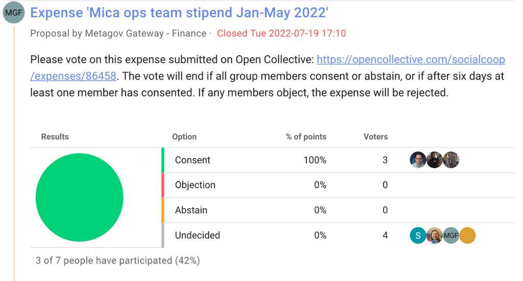

You can see there are rules about consent and abstention, as well as a veto rule in place. There is no quorum rule in place. The actual disbursement happens [via the Open Collective](https://opencollective.com/socialcoop#category-BUDGET) platform.

#### 5.2 Self-limits on financial capacity

Another interesting financial tooling anecdote comes from Piaille.fr, which has built into their bylaws a limitation on accumulation of funds:

> *I tried to make this as unpowerful as possible…. The non-profit organization, we forced ourselves not to be able to get more than five years of running expenses. So far, we only have banking expenses. So, maybe it’s up to 50 euros a year. So, we can’t receive any more than 250 euros. Inside our rules, we are due to send back all of the donations once we top that.*

#### 5.3 A gap in fiscal sponsorship

Fiscal sponsorship through the Open Collective Foundation (OCF) was a crucial tool for US-based servers to be able to legally receive funding without resorting to personal bank accounts or incorporation. OCF announced its dissolution in early 2024 with only weeks of notice to the organizations that relied on its services. The guidance given by OCF was for its orgs to find new fiscal sponsors, but at least one server team in our sample that used OCF feels that there are no longer any fiscal sponsors they can turn to. In particular, most fiscal sponsors require some sort of mission alignment, and it has been difficult finding sponsors who consider a general-purpose social media site to be aligned with their nonprofit mission. The server operator we spoke to feels like they have to either return to less structured forms of support or incur major legal costs to incorporate as a nonprofit. Right now they are forced to use a personal bank account while they figure out their next steps:

> *And so today it’s all going to a personal bank account…. But it’s not ideal, right? We need to move to a more stable structure that’s not dependent on any of us personally.*

There seems to be room for at least one Fediverse-focused fiscal sponsor organization in the ecosystem.

### **6. Legal compliance tools**

One small server moderator told us that legal compliance around CSAM is an area where they wish they had both technical tools (for reporting) and public legal guidance tools:

> *I would love to have an automated reporting flow that talks to whatever API the National Center for Missing and Exploited Children does in the US We’re legally required to file reports for CSAM. And a big thing I did last year was working with our lawyers to get a letter of opinion about where the lines are, and what we need to report and what we don’t. How does caching interact with that? I would love for there to be public, well-vetted legal guidance on what server admins should do–and also integrated reporting. So you can click a post to be like, send this report over with all the metadata required. Because right now I’m filing reports, I’m asking NCMEC for guidance, and they’ve never responded to me. So I don’t know if I’m doing the right thing or not.*

Some organizations like IFTAS are working on CSAM reporting tooling and providing legal guidance around laws like the EU Digital Services Act. But legal compliance in general is a wide ranging area and more tools (both technical and informational) are clearly needed, as admins of small servers feel more or less at sea on these issues.

### **7. Federation of moderation decisions**

> *Having a way to exchange data with other admins has always been a problem on the Fediverse.*

> *— a Hachyderm moderator*

As [far back as November 2016](https://github.com/mastodon/mastodon/issues/116), the Mastodon project has fielded feature requests from admins asking for some kind of formalized data sharing between administrators. Often this takes the form of requests for formal support for shared blocklists as described in 1.6 Shared blocklists and shared blocks, but other ideas in this space include feeds of moderation actions that servers can subscribe to. According to a moderator of Piaille.fr:

> *The idea […] was that we could kind of subscribe to a bigger instance or to a moderation instance, which would only publish moderation decisions. […] You could even figure out some way to subscribe only to a certain field of moderation decisions. […] But as of now, every Mastodon instance is all alone in moderation. And I think the Mastodon instances could also federate regarding moderation. […] It would be nice to subscribe to a place that publishes moderation decisions, etc. I was talking about grouping all of the French speakers, administrators, so like we could make big moderation decisions, national or for all the French-speaking instances, etc.*

In part this is in response to duplication of labor: a spam wave is likely to be unwelcome for almost all servers on the fediverse, so why should thousands of individual moderator teams have to spend time investigating and banning the same set of accounts or servers? A moderator of Social.coop explains:

> *#FediBlock is an example. Using a hashtag to communicate blocks, it’s—I get it, it’s cool, but my question is always, why is this not in ActivityPub? We should be federating moderation actions, right? We should be able to say, like—friend-to-friend instances…we are really friendly, I tell you about everybody we block, you know… I don’t think we do it enough, actually… We are being reactive is what I would say. I would love us to do better. Like, when we get a bunch of reports, in particular, of course, when we get forwarded reports from other instances, that’s an opportunity to engage with other instances.*

The reactive nature of moderating Mastodon servers came up in other interviews too. A moderator of Woof.group describes what for them is an ideal social structure for inter-server moderation:

> *I want there to be some kind of inter-server moderation discussion channel. Because DMing the other moderators, you never really know if you should DM [certain] accounts, which ones are announcement-only versus monitored, if you go to the personal account [of a moderator] or not. […] You want to inform a server, “well, no ban happened there, but we do care and what you reported was valid and here’s what we’re doing about it.” And a lot of what I try to do is a sort of political outreach to other instances, to let them know our stance on things. Honestly, it could be just email where we have a norm of monitored accounts and that’s where discussions go. It could be something that’s built into the server software and it would be cool if there were an inbox that multiple accounts had access to. […] I would love to be able to see on the report page “Here’s the remote instance that reported it” and have a chat system there where you can ask clarifying questions, inform them about the measures you’re taking, and so on, and it’s all retained in the report log.*

> *Because almost all of our inter-instance reports are things that we genuinely care about. We may differ in how we handle them, but they deserve communication. […] I would love a way to build those sorts of friendly political bridges with other instances in direct relation to reporting.*

They envision a proactive social regime where admins can, in the workflow of moderation itself, run decisions by other known-friendly admins on other servers to get feedback or additional information.

One moderator of hcommons.social speculates that this kind of network-building could result in direct mutual aid across servers, which could essentially share moderation burdens:

> *would allow moderators like me, instead of having to have an entire existence on one server and entire existence on another server, to be able to clock in and help out on different servers or services. That would be fun, because small instances could say, I can’t afford a moderator, I don’t have anybody, but I want to go away on vacation or something like that they could contact a low cost or free or volunteer, buy me a coffee type service that moderators could help out with. I think that would be nice. I don’t think I personally need it right now. But if I decide to go traveling the world for a month, what happens?*

Of course, in order to interact with known-friendly servers, there needs to be a way to flag a given group of servers as friendly relative to your own. A moderator of Social.coop says,

> *we don’t have a stream of, like, peer instances.… The question is how to find that beyond just…making friends. Which is nice, clearly. But I don’t even know how I would answer the question, “Which instances are in Social.coop’s space?”*

Having an inbox of known moderation activities, combined with an understanding of which servers are trusted servers, could let server operators set thresholds for automated moderation (“if X number of trusted servers have blocked this content, I will block it too”).

Federation of moderation decisions would reinforce the diplomatic nature of the relationship between servers. Ironically, this type of federation is closer to a classical political definition of “federation” as a kind of resource and information sharing rather than purely publishing things from one person’s outbox into another person’s inbox.

One stumbling block may be a cultural one. The Fediverse is, broadly speaking, staunchly anti-algorithm when it comes to social feeds. This is at least in part a reaction to the perceived over-reliance on algorithmic feeds on major social media platforms. This may introduce an antagonism toward certain forms of alliance-building tools. Again, the above moderator of Social.coop:

> *Once you start federating […] decisions and then you move to saying, “Several instances have reported this post, just downrank it, don’t show it automatically.” That’s very, very close to an algorithm. Which is like, I don’t know if you’ve seen, a lot of people don’t like the notion of an algorithm because of having been burned by corporate actors. Understandable. But the Fediverse is a bit—I mean, I don’t want to generalize, we are like a diverse set of people, but like, a fair chunk of people seem pretty against any kind of like notion of algorithm, which is why Mastodon, I think, lacks some of the tools it needs. […] We need to have the Fediverse, maybe move beyond a blanket “no” to algorithms, because I don’t think I see any other way to scale response. Like what I would love to do is say, yes, we need an algorithm, it means exactly this, and this is what it will unlock.*

This moderator points out that perhaps users should be more open to algorithmic decision making as long as the algorithms are transparent, understandable, and auditable.

### **8. Inter-server admin comms**

Some moderators and admins complained that while they would like to coordinate with (friendly) remote servers to discuss moderation decisions, the pathways and workflows for this are obscure and highly variable. Sometimes moderators form ad-hoc, cross server communities. An admin of Hachyderm tells us:

> *You have to have these little bubbles of contact, and I know in our documentation, we put how to reach us if you’re another server admin. Because eventually we were told that server admins were trying to reach us […] but they didn’t use the email address that’s affiliated with the server. And so we don’t know how they were trying to reach us, but to no fault of theirs. There’s not a place in the admin interface for them to go and do that.*

An admin of Woof.group tells us they’ve experienced similar difficulties with contacting remote admins:

> *I try to do a lot of messaging for anything that’s like a non-trivial mod action. I often will DM the moderator on the remote instance. I don’t often get responses to that. And I don’t know if it’s because DMs in Mastodon are easy to miss in the noise, or if it’s that we’re muted, or they’re just busy. I don’t know.*

And generally speaking, the results of contacting remote admins were mixed. Most of our participants reported never hearing back when they contact remote admins about moderation or federation decisions. Other participants said they generally hear back a majority of the time. Clearly there is some disconnect here.

The Hachyderm admin went on to discuss a possible solution to the difficulty of admin contact:

> *It would be really nice to see a way for whomever has moderation privileges on the server to have a sort of inbox-y type setup or something between servers, and just let the software, Mastodon or whatever, handle it itself. And if admin communication needs to happen, it can just happen really directly, and you don’t have to worry about [forming your own] bubbles. […] And then you know if your messages are at least being received. And I think that would stir down a lot of inter-instance conflict, which there seems to be a lot of.*

These could also form a basis for communication around other kinds of non-moderation coordination needed between admins. An admin for Woof.group told us that,

> *when another instance goes down or is going to shut down, sometimes we’ll coordinate with their mods and make an announcement like, “Hey, if you’re looking for a home, we’re pretty aligned, just mention where you’re coming from and we’ll give you an account here.”*

This is another place where flagging of known-friendly servers could come in handy, as discussed in the Federation of moderation decisions section. In fact, both the manual inter-admin communications discussed in this section and the automated federation of moderation discussed in the last section would benefit from the same standardized solutions: perhaps a “.well-known” URI provided as an inbox for incoming messages and a “Moderation” activity type that can be used for these communications.

### **9. Tooling recommendations**

In addition to the high-level recommendations near the beginning of this document, we’ve written an accompanying document, **Fediverse Governance Opportunities for Funders and Developers**, to collect the many recommendations we’ve made throughout this findings report. We’re also making a series of specific recommendations here that deal exclusively with software/tooling issues in close proximity to the tooling-related observations above.

**Recommendations for core software developers:**

- **Build pathways for inter-server communication:** In Mastodon, there is no clear path for a moderator on one server to communicate about or appeal a cross-server decision with a moderator on another server. This is a non-trivial feature, which would require attention to safety and consent, but a bare minimum, if each server identified an inbox for inbound admin communications, future collaborative moderation tooling would have a canonical way to send messages intended for a remote moderation team. Standardization of this inbox should be an urgent priority. (Building affordances for both blocklist and allow-list management into this layer or the more ambitious governance dashboard proposed below would allow for more sophisticated and potentially less time-consuming methods of managing these relationships.)
- **Enable allow-list federation:** More rederated projects—including Mastodon—should make it easy for server teams to adopt other forms of federation aside from the “permissive” model now used by Mastodon. Alternatives like allow-list federation are poorly supported, particularly in Mastodon, in which allow-list federation is technically possible but requires setting a Unix environment variable and lacks other first-class UI support.
- **Standardize and enrich tools that control who gets to sign up for an account.** The ability to control account registration was valuable for nearly all the teams we spoke with. Non-Mastodon federated software should consider matching Mastodon’s suite of options for registration as detailed above. There’s room for more innovation on these features and options within Mastodon as well: some server teams ran more expansive registration processes outside of Mastodon to allow for richer interaction with potential members.

**Recommendations for third-party and core software developers:**

- **Create a governance-focused dashboard that interfaces with many Fediverse projects:** A governance dashboard distinct from internal-facing content moderation could address both **server leadership** and **federated diplomacy** tasks. This could be a place where mods interact with remote server teams, easing appeals and cross-server discussions, where server leaders can easily create straw polls and other communications to seek input from their members, and where information-sharing alliances such as the coalitional “neighborhoods” or “caracoles” discussed in 3.2 Easing institutions into the Fediverse are formalized via the ActivityPub protocol.
- **Build CSAM-handling tools that are well-suited to Fediverse governance models:** As the Fediverse and other decentralized services grow in popularity, it will be necessary to either educate third party providers of CSAM-filtering tools (Thorn, PhotoDNA, etc.) and/or build new content filtering software created from the ground up for small servers rather than large companie. Partnerships like the one between IFTAS and Thorn discussed in 1.10 Content filtering are a useful stopgap, but ultimately, if they’re going to accommodate new network structures, these providers need to move from an enterprise, handshake-deal business model to a “b2b” model in which the business entity on the other end is a Fediverse server team (or coalition).
- **Develop better moderation tooling:** Many participants described the need for better content moderation tooling that is less manual and labor-intensive, and which includes richer support for communicating with members and other moderators. Developers of core Fediverse software should invest in better tooling to meet these needs, but third-party developers can also contribute to this effort. (One example of more fine-tuned technical infrastructure in non-Mastodon Fediverse software is Pleroma’s [Message Rewrite Facility](https://docs.pleroma.social/mrf.html), a highly customizable rules system for automated content moderation.) Mastodon, at least, provides API access to their reporting interface, which allows third parties to create moderation tools for or integrate existing moderation tools into Mastodon servers. Building these tools would be a productive area for developers (and funders) interested in fostering better moderation across the Fediverse.
- Core server software should provide the ability for secure, multi-access accounts that are shared by members of their server team who need to communicate with server users. This would allow for a formalization of the creation of generic user-facing administrative accounts like the one discussed in 1.8 User-facing generic moderation account.
- Legal compliance tools, such as automated NCMEC reporting, or settings to handle requirements of privacy laws like GDPR where applicable, would help ease the anxiety of server teams and encourage communities to set up new servers. Third-party projects are a likely place for these tools, as these tools would need to be specialized for the legal needs of different regions of the world.

## **Section Six: The Case for the Fediverse**

The voices of the people who let us ask them hours and hours of questions have been a guiding force throughout this project. In this closing section, we’re going to run them without commentary.

> *I think that as a civilization, the constraints and guidelines and affordances that contain the conversations we have with ourselves is an issue of central importance, and clearly the internet has affected that existentially, the way the humans and human organizations converse with each other. And there have been repeated attempts to guide that through the conduit of privately-owned, centralized, venture-funded capitalist enterprises, and they have consistently failed. Cory Doctorow is right, you know?*

> *I think the jury has been out and it’s come in, and we have learned that social online conversations under the auspice of a central capitalist controlling organization is not a recipe for success. And the Fediverse is the best instance I’ve seen of an alternative that might work, and it’s based on the same kind of core structure that email has been. And email is another thing that has managed to survive through all the decades without being monopolized by anybody, and it can’t be because you can always get a new email address, right?*

> *So I think the Fediverse is actually existentially important to the quality and success of human discourse—and it’s by a wide margin I think the most interesting thing that’s going on in the whole human-oriented technology landscape.*

> *—Tim Bray, a founding member at CoSocial.ca*

> *It’s my favorite social media! It’s interesting, like a lot of people describe this kind of toxicity on Fediverse and I believe them—I think because of the people and communities I’ve cultivated, and maybe also my identity and things like that, that has not been my experience. When I wake up in the morning and wonder what’s on my social media feeds, I’m always much more excited to check what’s on Social.coop than what’s anywhere else.*

> *…a theory I have is that we’re entering a moment where like the VC accelerated social media phase is maybe passing—where all the money is going more toward entertainment platforms. I think of TikTok in that category, it’s largely an entertainment platform, and…maybe social media can be boring again. I don’t know if this is really true, but maybe AI would just mean like…okay, the AIs are more interesting to doomscroll on than humans.*

> *So let’s just make social media slow and really hold it in contrast to that other stuff and not assume it’s ever going to make money, you know, and just assume it’s this public infrastructure that we use when, when we want to talk to actual people. I fear for the other stuff, but I guess I think of tech as a wildfire—it burns really quickly. And we get a lot of wildfires out here, and there’s the front of it, where the blaze is, and then once it’s burnt over, that’s when cool things start growing up. They grow much slower, and they find their way through the, you know, through the burned trees and new life happens. I kind of hope we’re entering that phase of social media that we’re done with the fast burn. And maybe it had to happen.*

> *But it’s not that old, any of this stuff. And if the rest of the future of social media is not something that VCs think they can make billions and billions of dollars on, fantastic.*

> *—Nathan Schneider, founding member of Social.coop and author of Governable Spaces: Democratic Design for Online Life*

> *My hope is that the technology follows—and if you look at the things like Letterbook, Go To Social, a possible Mastodon fork, these are all things that could move things in a direction that really distills the key value of the sort of queer-centricity, which has largely been lost in the Fediverse as a whole, I would say, because of the huge size. But as this happens, I think there’s a chance to restore more of that.*

> *The focus on consent and privacy, I think, is really a distinguishing factor from the directions that Bluesky and all are [taking] and there’s a need for something like that. Again, that’s not where mastodon.social and all are taking things.… The big wildcard in all that is, can it overcome the whiteness factor? And that’s a big question…*

> *Today’s Fediverse is a prototype. Prototypes can sometimes evolve into the actual sustainable thing, or sometimes that it evolves into the V1 and V2 happens in parallel, but this is, you know, it’s a great test bed for this stuff and both for the instance governance and then even more so for the cross, for the cross instance federation stuff. It’s the first time, it’s really a prototype at scale that lets us discover these things.*

> *I think the lessons, no matter what happens to today’s ActivityPub, Fediverse, you know—the pressures of corporatization are going to lead to huge changes… But the learning is valuable because this core, you know, the queer friendly, indie, we don’t want to be commoditized core. That’s a network that’s going to largely survive in various forms on whatever platform it is.*

> *—Jon Pincus, IFTAS advisor and content moderation researcher*

> *I spend much less time on Fediverse stuff than I did on Twitter. And that has been better for me than not. I explain it to non Fediverse people, it’s like methadone versus heroin or something. It feels pretty good, but I don’t feel quite as compelled to check it all the time. And that’s probably for the best, you know? People are like, “Oh, is it cool? Do you like it like Twitter?” I don’t like it like Twitter. And that’s why I think it’s better…*

> *I think the thing that unites most of our team on this front is we think it’s important and a real good, even though the software in this space is pretty clunky, to have people have a non-commercial option for these things. And an option of not being shovel-fed rage bait, basically.*

> *—Phil Siino Haack, advisor to SFBA.social*

> *We’ve all seen a lot of things rise and fall quickly and slowly. And as someone who’s just—I’m so in love with the web and what it means for us as a species, as an animal with eyes and a brain and we get to share and talk!*

> *And I would hate for us to lose this opportunity to reset the last 15 years of walled-garden, surveillance, data-mining weirdness that we milked out of this technology. And return it to the ability to offer folks the freedom to associate and freedom to civil speech…because we’re just too cautious as a community to let more people in, to enjoy the thing we built.*

> *…at some point, I think we need to break the glass and understand that the protocol and the platforms exist so that people can associate, connect, communicate in whatever fashion they want to, whether that’s a group of two people, 10 people or a million people. There are safe spaces and we need to preserve those safe spaces. But I don’t see it as a binary proposition. Not that I’m saying we should make unsafe spaces, but there’s a tremendous amount of steam in this engine. And if we don’t figure out a way to be proud and expressive about it, I think we’ll lose it as well. Because it will just die on the vine…*

> *We’re in a very small bubble. We have 15 million accounts, 2 million active, something like that. And so we’re highly presented with the troubles of the day in our bubble. I would love to see all of these conversations elevated so that there’s a story to tell that is meaningful and can be consumed by the folks who don’t know why they would enjoy this experience. Whatever that might be. Whether it’s a safe space for furries or a massive connection of people around history or whatever it is.*

> *Hopefully [IFTAS’s governance/moderation template work] a one piece of a very large puzzle of adding some robustness and integrity, some structure to all of this so it can grow cautiously, guardedly, mindfully, provide everything, all the benefits that we’ve eked out of it so far, while providing space for the not us.… This is why I curate that map of the world of Mastodon servers. When I saw a server pop up in Tunisia—”Yes, yes!” Only the people in Tunisia should be in charge of how Tunisians communicate with each other. It’s not a San Francisco conversation.*

> *—Jaz-Michael King, Executive Director of IFTAS*

> *I think if we can keep enough people active and involved who are good communicators—it’s had incredible reach, the social web in general. It’s expanded so many horizons. I mean, there are experiences I’ve had that I never would have thought of without it. So I’m still enthused about that. It’s still happening. I still meet fascinating new people.*

> *And at least in the Fediverse, the signal is still very high compared to the noise, whereas, you know, the collapsing legacy platforms are all noise at this point, doing more damage than good. I want to see things like federated social media set a better standard. I think it can, I don’t know that it will. But yeah, that’s why I’m still here.*

> *—Johanna B.. moderator for Wandering Shop and CoSocial.ca*